# **Stat479 Rough Draft**

Olivia Plamann, Grace Campbell, Supraja Battula, Justin Yang, Huailin Tang

4/29/2022

# **Introduction**

- Social media platforms like Twitter have been an outlet for many individuals to express their thoughts and beliefs, especially during times of isolation such as the COVID-19 pandemic. We are interested in visualizing and analyzing Tweet Sentiment and Hashtags throughout the pandemic, and more specifically how these trends relate to COVID case counts and restriction periods. We answered our question by parallelizing our computations using the High Performance Computing Cluster (HPC) using shell scripting and R code. In this code, we ran linear and logistic regressions on COVID-19 case counts and restrictions, produced various time series graphs to focus on Tweet Sentiment, and used bar plots to visualize the most common hashtags in 2022.

# **Data Collection**

**Sentiment and Covid Data**

```
##   Year Month Sentiment    Count   Cases Restrctions
## 1 2020     1  negative  3936307   37606          no
## 2 2020     2  negative  8409525   70123          no
## 3 2020     3  negative 16533099 1102813         yes
## 4 2020     4  negative 23045515 2433616         yes
## 5 2020     5  negative 32669339 3247922         yes
## 6 2020     6  negative 41515213 4434465         yes
```

# **Statistical Analysis**

- For the statistical computations, we first ran a linear regression model to investigate the relationship between count of negative sentiment Tweets and the count of COVID-19 cases from January 2020 to March 2022. It resulted in a p-value of 0.783 signifying no relationship between the two variables.

### Negative Tweets vs Number of Covid Cases Linear Regression

```
##
## Call:
## lm(formula = data$Count ~ data$Cases)
##
## Residuals:
##       Min        1Q    Median        3Q       Max
## -25520247  -8067327    810311   7879446  20788640
##
## Coefficients:
##              Estimate Std. Error t value Pr(>|t|)
## (Intercept) 2.946e+07  3.145e+06   9.367 1.18e-09 ***
## data$Cases  3.320e-02  1.190e-01   0.279    0.783
## ---
## Signif. codes:  0 '***' 0.001 '**' 0.01 '*' 0.05 '.' 0.1 ' ' 1
##
## Residual standard error: 11940000 on 25 degrees of freedom
## Multiple R-squared:  0.003103,   Adjusted R-squared:  -0.03677
## F-statistic: 0.07782 on 1 and 25 DF,  p-value: 0.7826
```

- However, we then graphed these variables to visualize their relationship, or lack thereof, and found that a subset of the months in this time period seemed to show similar trends.

**Count of Covid Cases vs Negative Tweets**

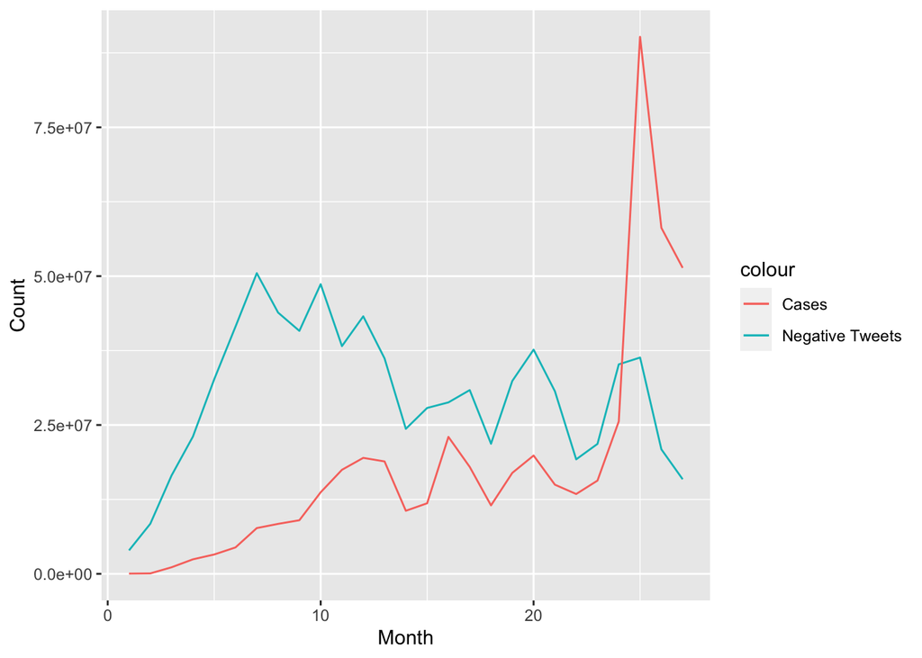

### Subset Analysis: Negative Tweets vs Number of Covid Cases Linear Regression

```
##
## Call:
## lm(formula = count_sub ~ case_sub)
##
## Residuals:
##      Min       1Q   Median       3Q      Max
## -7947232 -3953625   993477  3323487 10082564
##
## Coefficients:
##              Estimate Std. Error t value Pr(>|t|)
## (Intercept) 1.341e+07  6.459e+06   2.076   0.0601 .
## case_sub    1.015e+00  3.701e-01   2.742   0.0179 *
## ---
## Signif. codes:  0 '***' 0.001 '**' 0.01 '*' 0.05 '.' 0.1 ' ' 1
##
## Residual standard error: 5800000 on 12 degrees of freedom
## Multiple R-squared:  0.3852, Adjusted R-squared:  0.334
## F-statistic: 7.518 on 1 and 12 DF,  p-value: 0.01787
```

**Count of Covid Cases vs Negative Tweets Subset**

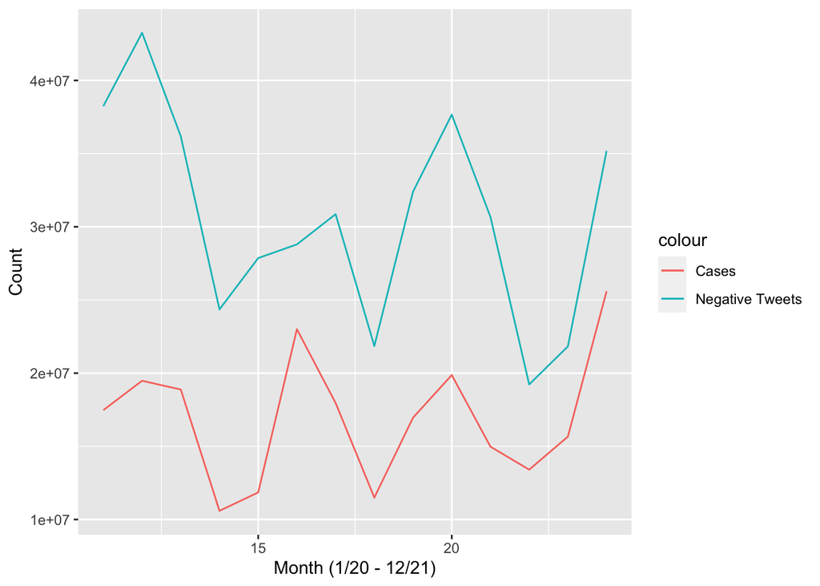

```
##
## Call:
## glm(formula = data$Count ~ data$Restrctions)
##
## Deviance Residuals:
##       Min         1Q     Median         3Q        Max
## -20306212   -7121707     735246    7980215   15048494
##
## Coefficients:
##                     Estimate Std. Error t value Pr(>|t|)
## (Intercept)         24242519    2897842   8.366 1.03e-08 ***
## data$Restrctionsyes 11207994    4024321   2.785   0.0101 *
## ---
## Signif. codes:  0 '***' 0.001 '**' 0.01 '*' 0.05 '.' 0.1 ' ' 1
##
## (Dispersion parameter for gaussian family taken to be 1.091674e+14)
##
##     Null deviance: 3.5759e+15  on 26  degrees of freedom
## Residual deviance: 2.7292e+15  on 25  degrees of freedom
## AIC: 953.29
##
## Number of Fisher Scoring iterations: 2
```

- Lastly, we graphed the distributions of negative sentiment Tweets according to restriction status and were able to visualize the relationship between the two variables.

**Distribution of Negative Tweets by Restriction Status**

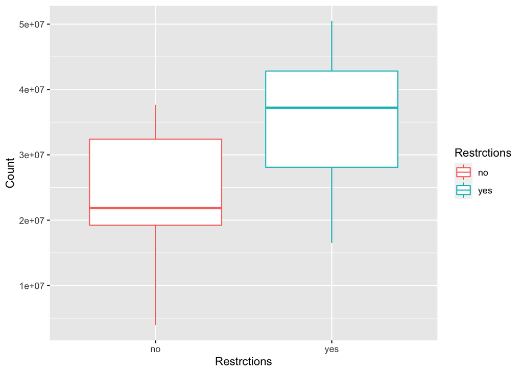

- From the above graphs we can see that the number of negative tweets had a stronger overall relationship with societal restrictions than with number of Covid cases, suggesting that the hindrance of social liberties has a more profound effect on humans than the knowledge of millions of people contracting Covid.

### Sentiment Analysis Over Time

- Next, we considered all sentiments’ Tweet count and ratios for each of the three years by producing several time series graphs.

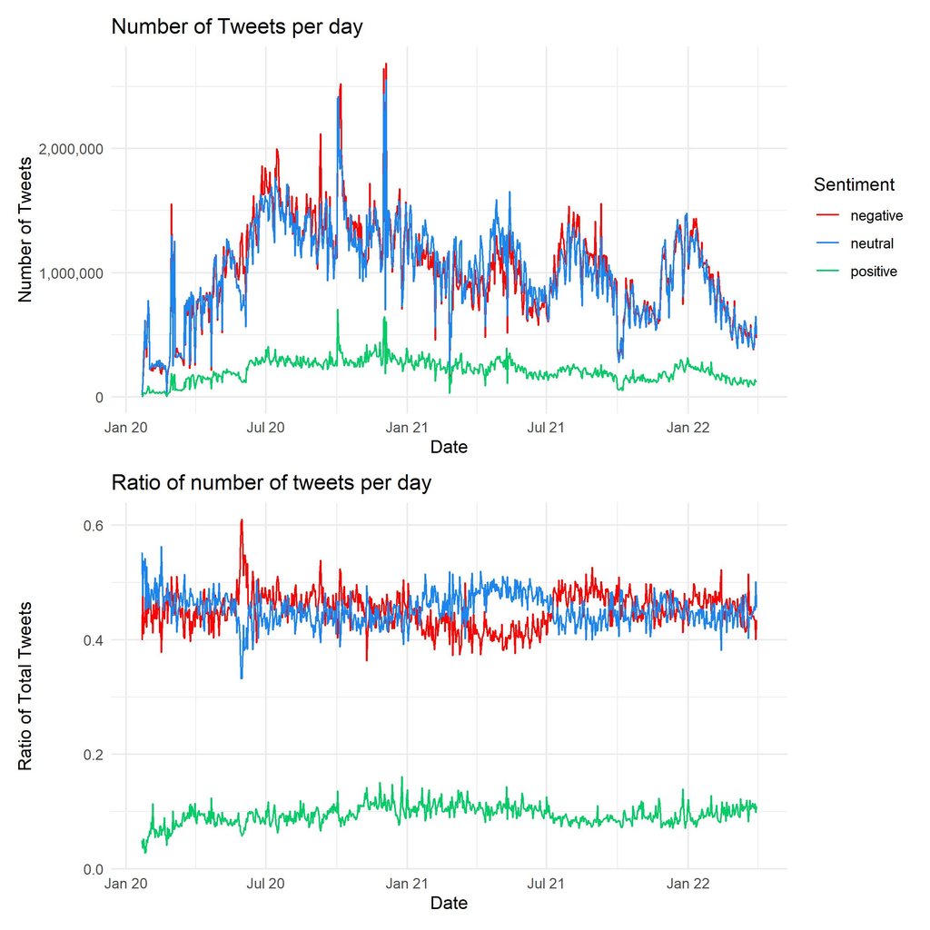

- We noticed the counts of negative and neutral Tweets were higher, with the peak of negativity coming around July 2020 amidst the first summer of the pandemic. As a result, we decided to consider how these negative Tweets compared year to year. We produced a time series plot indexed by year. While incomplete for several months in 2022, we notice a gradual increase in the total number of negative Tweets for 2020, as well as the cyclic pattern illustrated in 2021 and partially in 2022.

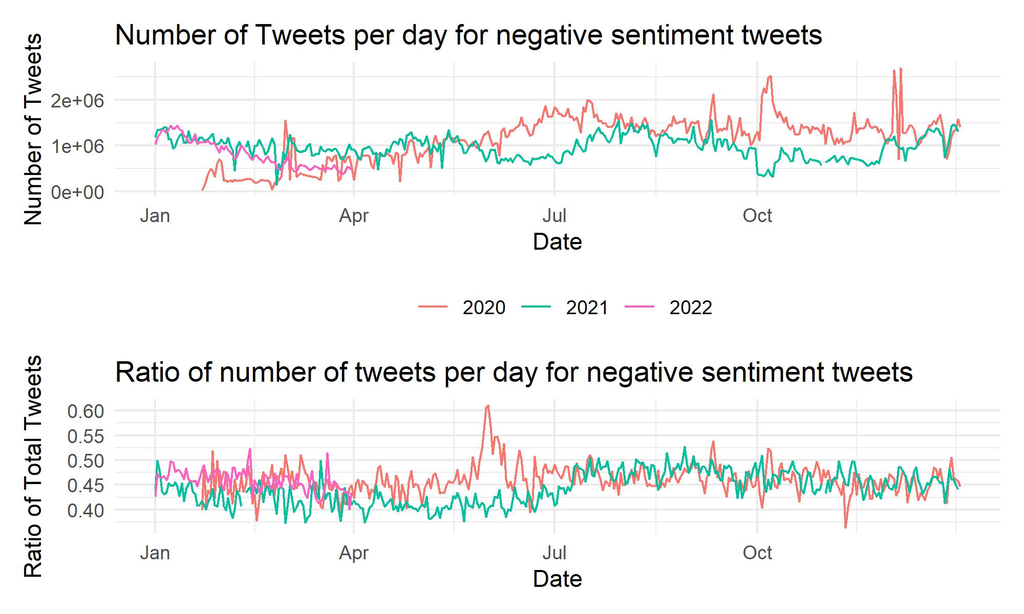

### Hashtag Trend Analysis

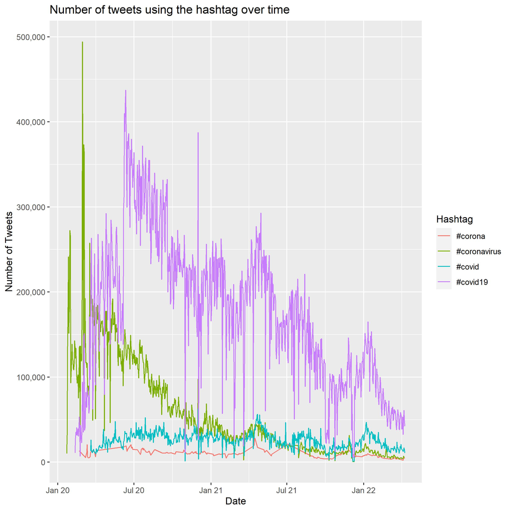

**Most Popular Hashtags 2022**

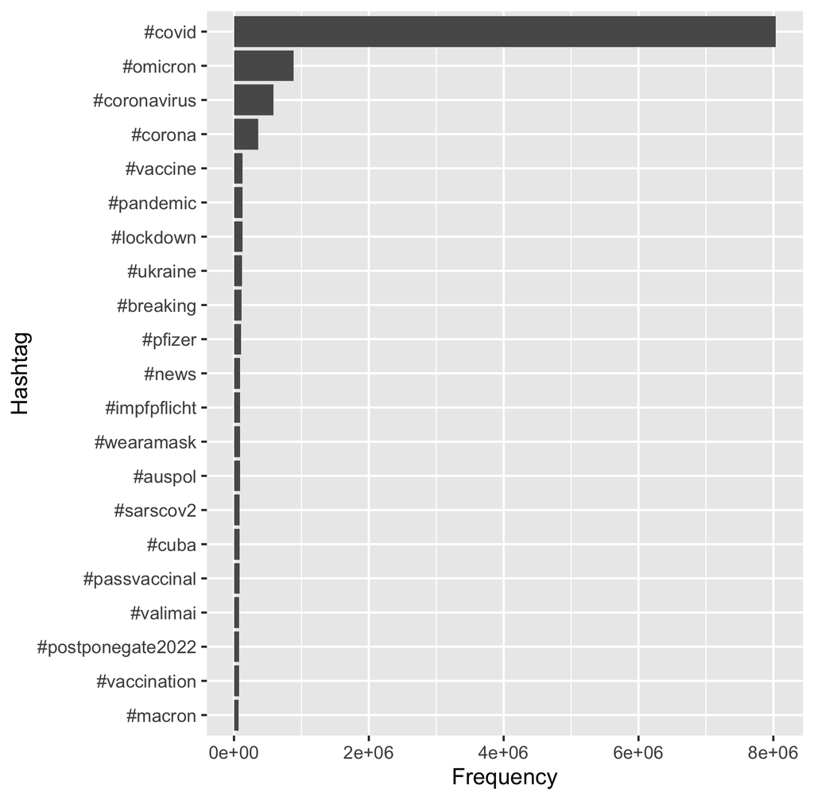

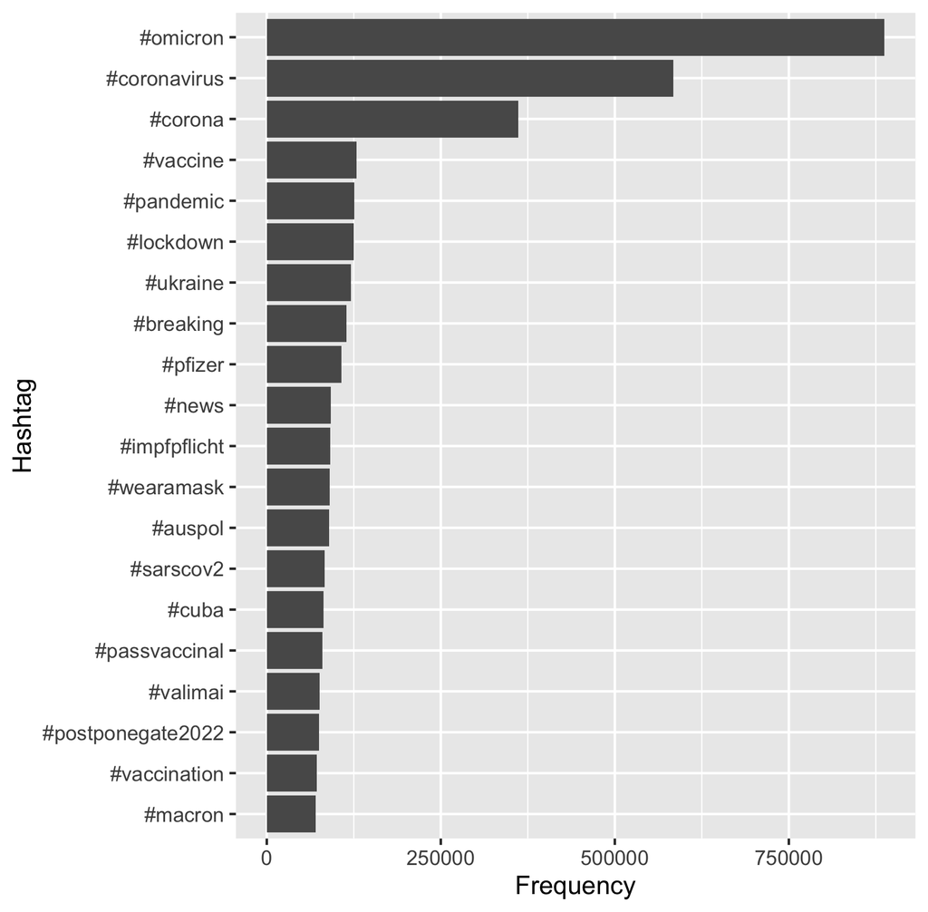

# **Job Description**

- Our jobs typically took around 5-10 minutes to complete, but drastically increased to about an hour or more as more individuals ran their computations on Slurm. We were able to use the default 4 GB of memory per CPU allocated on the Slurm scheduler for all of our jobs.
- From our analysis, we learned a significant amount about Tweet Sentiment and Hashtags during the COVID-19 pandemic. However, there certainly are weaknesses to our analysis. For example, we are putting trust in the sentiment analysis and prediction methods the creators of the dataset chose. While the algorithm has a good reputation, we did not perform the deep learning predictive computations ourselves and are putting trust into someone else’s work for our analysis which may result in problems rolling over.

# **Conclusion**

- In light of our analysis, we learned that there is a significant relationship between negative Tweets and the count of COVID cases specifically from November 2020 to December 2021. We also learned the relationship between number of negative Tweets and restriction status was significant. From the time series, the high count and ratios of negative and neutral Tweets on the Twitter platform remained consistent each year. We found that #covid was the most common hashtag of 2022 thus far, and was a strong outlier compared to other common hashtags. In future work, we might find it interesting to focus on a subset in time like the events occurring in Ukraine, the Olympics, or even the Superbowl.